# A2 LR

```python
import _pickle as pickle
import matplotlib.pyplot as plt
import numpy as np
```

set up some basic functions

```python
def softmax(logits):
    """ This function applies softmax function to the logits.

    Args:
    - logits (ndarray (shape: (N, K))): A NxK matrix consisting N K-dimensional logits.

    Output:
    - (ndarray (shape: (N, K))): A NxK matrix consisting N K-categorical distribution.
    """
    e_logits = np.exp(logits - np.max(logits, axis=1, keepdims=True))
    return e_logits / np.sum(e_logits, axis=1, keepdims=True)

def load_pickle_dataset(file_path):
    """ This function loads a pickle file given a file path.

    Args:
    - file_path (str): The path of the pickle file

    Output:
    - (dict): A dictionary consisting the dataset content.
    """
    return pickle.load(open(file_path, "rb"))

def visualize_2d_data(X, y):
    """ This function generates a 2D scatter plot given the inputs and their corresponding labels.
    Inputs with different classes are represented with different colours.

    Args:
    - X (ndarray (shape: (N, D))): A NxD matrix consisting N D-dimensional inputs.
    - y (ndarray (shape: (N, 1))): A N-column vector consisting N scalar outputs (labels).
    """
    assert len(X.shape) == len(y.shape) == 2, f"Input/output pairs must be 2D-arrays. X: {X.shape}, y: {y.shape}"
    (N, D) = X.shape
    assert N == y.shape[0], f"Number of samples must match for input/output pairs. X: {N}, y: {y.shape[0]}"
    assert D == 2, f"Expected 2 features. Got: {D}"
    assert y.shape[1] == 1, f"Y must be a column vector. Got: {y.shape}"

    # ====================================================
    # TODO: Implement your solution within the box
    plt.scatter(X[:, 0], X[:, 1], c = y)

    # ====================================================
```

## A2 Logistic Regression

*Implementation of logistic regression:*

```python
class LogisticRegression:
    def __init__(self,
                 num_features,
                 num_classes,
                 rng=np.random):
        """ This class represents a multinomial logistic regression model.
        NOTE: We assume lables are 0 to K - 1, where K is number of classes.

        self.parameters contains the model weights.
        NOTE: Bias term is the first term

        TODO: You will need to implement the methods of this class:
        - _compute_loss_and_gradient: ndarray, ndarray -> float, ndarray

        Implementation description will be provided under each method.

        For the following:
        - N: Number of samples.
        - D: Dimension of input features.
        - K: Number of classes.

        Args:
        - num_features (int): The number of features in the input data.
        - num_classes (int): The number of classes in the task.
        - rng (RandomState): The random number generator to initialize weights.
        """
        self.num_features = num_features
        self.num_classes = num_classes
        self.rng = rng

        # Initialize parameters
        self.parameters = np.zeros(shape=(num_classes, self.num_features + 1))

    def init_weights(self, factor=1, bias=0):
        """ This randomly initialize the model weights.

        Args:
        - factor (float): A constant factor of the randomly initialized weights.
        - bias (float): The bias value
        """
        self.parameters[:, 1:] = factor * self.rng.rand(self.num_classes, self.num_features)
        self.parameters[:, 0] = bias

    def _compute_loss_and_gradient(self, X, y, alpha_inverse=0, beta_inverse=0):
        """ This computes the negative log likelihood (NLL) or negative log posterior and its gradient.

        NOTE: When we have alpha_inverse != 0 or beta_inverse != 0, we have negative log posterior (NLP) instead.
        NOTE: For the L2 term, drop all the log constant terms and cosntant factor.
              For the NLL term, divide by the number of data points (i.e. we are taking the mean).
              The new loss should take the form:
                  E_new(w) = (NLL_term / N) + L2_term
        NOTE: Compute the gradient based on the modified loss E_new(w)

        Args:
        - X (ndarray (shape: (N, D))): A NxD matrix consisting N D-dimensional inputs.
        - y (ndarray (shape: (N, 1))): A N-column vector consisting N scalar outputs (labels).
        - alpha_inverse (float): 1 / variance for an optional isotropic Gaussian  prior (for the weights) on NLP.
                                NOTE: 0 <= alpha_inverse. Setting alpha_inverse to 0 means no prior on weights.
        - beta_inverse (float): 1 / variance for an optional Gaussian prior (for the bias term) on NLP.
                                NOTE: 0 <= beta_inverse. Setting beta_inverse to 0 means no prior on the bias term.

        Output:
        - nll (float): The NLL (or NLP) of the given inputs and outputs.
        - grad (ndarray (shape: (K, D + 1))): A Kx(D + 1) weight matrix (including bias) consisting the gradient of NLL (or NLP)
                                              (i.e. partial derivatives of NLL (or NLP) w.r.t. self.parameters).
        """
        (N, D) = X.shape
        # ====================================================
        # TODO: Implement your solution within the box
        K = self.num_classes
        #add bias term
        X = np.hstack((np.ones(shape=(N, 1), dtype=np.float), X))
        #construct one hot encoding vector
        yhot = np.zeros((N,K))
        for i in range(0,N):
            k = y[i]
            yhot[i,k] = 1


        w = self.parameters
        z = X @ w.T
        p = softmax(z)
        logp = np.log(p)
        #calculate negative log likelihood based on given formula from handout
        nlterm = (-1/N)*np.trace(yhot @ logp.T)
        #construct matrix C
        varvec = np.zeros(D+1)
        varvec[0] = beta_inverse
        varvec[1: D+1] = alpha_inverse
        c = np.diag(varvec)

        #construct l2 based on given formula and its gradient based on derived
        #formula
        l2 = np.trace(self.parameters @ c @ self.parameters.T)
        l2grad = self.parameters @ (c+c.T)

        nll = l2 + nlterm
        #construct gradient of nll based on derived formula
        grad = l2grad + (-1/N)*((yhot - p).T @ X)


        # ====================================================
        return nll, grad

    def learn(self,
              train_X,
              train_y,
              num_epochs=1000,
              step_size=1e-3,
              check_grad=False,
              verbose=False,
              alpha_inverse=0,
              beta_inverse=0,
              eps=np.finfo(np.float).eps):
        """ This performs gradient descent to learn the parameters given the training data.

        NOTE: This method mutates self.parameters

        Args:
        - train_X (ndarray (shape: (N, D))): A NxD matrix consisting N D-dimensional training inputs.
        - train_y (ndarray (shape: (N, 1))): A N-column vector consisting N scalar training outputs (labels).
        - num_epochs (int): Number of gradient descent steps
                        NOTE: 1 <= num_epochs
        - step_size (float): Gradient descent step size
        - check_grad (bool): Whether or not to check gradient using finite difference.
        - verbose (bool): Whether or not to print gradient information for every step.
        - alpha_inverse (float): 1 / variance for an optional isotropic Gaussian  prior (for the weights) on NLL.
                                NOTE: 0 <= alpha_inverse. Setting alpha_inverse to 0 means no prior on weights.
        - beta_inverse (float): 1 / variance for an optional Gaussian prior (for the bias term) on NLL.
                                NOTE: 0 <= beta_inverse. Setting beta_inverse to 0 means no prior on the bias term.
        - eps (float): Machine epsilon

        ASIDE: The design for applying gradient descent to find local minimum is usually different from this.
               You should think about a better way to do this! Scipy is a good reference for such design.
        """
        assert len(train_X.shape) == len(train_y.shape) == 2, f"Input/output pairs must be 2D-arrays. train_X: {train_X.shape}, train_y: {train_y.shape}"
        (N, D) = train_X.shape
        assert N == train_y.shape[0], f"Number of samples must match for input/output pairs. train_X: {N}, train_y: {train_y.shape[0]}"
        assert D == self.num_features, f"Expected {self.num_features} features. Got: {D}"
        assert train_y.shape[1] == 1, f"train_Y must be a column vector. Got: {train_y.shape}"
        assert 1 <= num_epochs, f"Must take at least 1 gradient step. Got: {num_epochs}"

        nll, grad = self._compute_loss_and_gradient(train_X, train_y, alpha_inverse, beta_inverse)

        # Check gradient using finite difference
        if check_grad:
            original_parameters = np.copy(self.parameters)
            grad_approx = np.zeros(shape=(self.num_classes, self.num_features + 1))
            h = 1e-8

            # Compute finite difference w.r.t. each weight vector component
            for ii in range(self.num_classes):
                for jj in range(self.num_features + 1):
                    self.parameters = np.copy(original_parameters)
                    self.parameters[ii][jj] += h
                    grad_approx[ii][jj] = (self._compute_loss_and_gradient(train_X, train_y, alpha_inverse, beta_inverse)[0] - nll) / h

            # Reset parameters back to original
            self.parameters = np.copy(original_parameters)

            print(f"Negative Log Probability: {nll}")
            print(f"Analytic Gradient: {grad.T}")
            print(f"Numerical Gradient: {grad_approx.T}")
            print("The gradients should be nearly identical.")

        # Perform gradient descent
        for epoch_i in range(num_epochs):
            original_parameters = np.copy(self.parameters)
            # Check gradient flow
            if np.linalg.norm(grad) < eps:
                print(f"Gradient is close to 0: {eps}. Terminating gradient descent.")
                break

            # Determine the suitable step size.
            step_size *= 2
            self.parameters = original_parameters - step_size * grad
            E_new, grad_new = self._compute_loss_and_gradient(train_X, train_y, alpha_inverse, beta_inverse)
            assert np.isfinite(E_new), f"Error is NaN/Inf"

            while E_new >= nll and step_size > 0:
                step_size /= 2
                self.parameters = original_parameters - step_size * grad
                E_new, grad_new = self._compute_loss_and_gradient(train_X, train_y, alpha_inverse, beta_inverse)
                assert np.isfinite(E_new), f"Error is NaN/Inf"

            if step_size <= eps:
                print(f"Infinitesimal step: {step_size}. Terminating gradient descent.")
                break

            if verbose:
                print(f"Epoch: {epoch_i}, Step size: {step_size}, Gradient Norm: {np.linalg.norm(grad)}, NLL: {nll}")

            # Update next loss and next gradient
            grad = grad_new
            nll = E_new

    def predict(self, X):
        """ This computes the probability of labels given X.

        Args:
        - X (ndarray (shape: (N, D))): A NxD matrix consisting N D-dimensional inputs.

        Output:
        - probs (ndarray (shape: (N, K))): A NxK matrix consisting N K-probabilities for each input.
        """
        (N, D) = X.shape
        assert D == self.num_features, f"Expected {self.num_features} features. Got: {D}"

        # Pad 1's for bias term
        X = np.hstack((np.ones(shape=(N, 1), dtype=np.float), X))

        # This receives the probabilities of class 1 given inputs
        probs = softmax(X @ self.parameters.T)
        return probs
```

*Training of logistic regression:*

```python
def train(train_X,
          train_y,
          test_X=None,
          test_y=None,
          data_preprocessing = lambda X: X,
          factor=1,
          bias=0,
          alpha_inverse=0,
          beta_inverse=0,
          num_epochs=1000,
          step_size=1e-3,
          check_grad=False,
          verbose=False):
    """ This function trains a logistic regression model given the data.

    Args:
    - train_X (ndarray (shape: (N, D))): A NxD matrix consisting N D-dimensional training inputs.
    - train_y (ndarray (shape: (N, 1))): A N-column vector consisting N scalar training outputs (labels).
    - test_X (ndarray (shape: (M, D))): A NxD matrix consisting M D-dimensional test inputs.
    - test_y (ndarray (shape: (M, 1))): A N-column vector consisting M scalar test outputs (labels).
    - data_preprocessing (ndarray -> ndarray): A data-preprocessing function that is applied on both the
                                               training and test inputs.

    Initialization Args:
    - factor (float): A constant factor of the randomly initialized weights.
    - bias (float): The bias value

    Learning Args:
    - num_epochs (int): Number of gradient descent steps
                        NOTE: 1 <= num_epochs
    - step_size (float): Gradient descent step size
    - check_grad (bool): Whether or not to check gradient using finite difference.
    - verbose (bool): Whether or not to print gradient information for every step.
    """
    train_accuracy = 0
    # ====================================================
    # TODO: Implement your solution within the box
    # Step 0: Apply data-preprocessing (i.e. feature map) on the input data
    train_X = data_preprocessing(train_X)
    test_X = data_preprocessing(test_X)
    # Step 1: Initialize model and initialize weights
    K = train_y.max() + 1
    D = train_X.shape[1]
    LR = LogisticRegression(D,K)
    LR.init_weights()
    # Step 2: Train the model
    LR.learn(train_X, train_y,num_epochs= num_epochs,
              step_size= step_size,
              check_grad= check_grad,
              verbose=verbose,
              alpha_inverse=alpha_inverse,
              beta_inverse=beta_inverse,
              )
    # Step 3: Evaluate training performance
    train_probs = LR.predict(train_X)
    # ====================================================
    train_preds = np.argmax(train_probs, axis=1)
    train_accuracy = 100 * np.mean(train_preds == train_y.flatten())
    print("Training Accuracy: {}%".format(train_accuracy))

    if test_X is not None and test_y is not None:
        test_accuracy = 0
        # ====================================================
        # TODO: Implement your solution within the box
        # Evaluate test performance
        test_probs = LR.predict(test_X)
        # ====================================================
        test_preds = np.argmax(test_probs, axis=1)
        test_accuracy = 100 * np.mean(test_preds == test_y.flatten())
        print("Test Accuracy: {}%".format(test_accuracy))

def feature_map(X):
    """ This function perform applies a feature map on the given input.

        Given any 2D input vector x, the output of the feature map psi is a 3D vector, defined as:
        psi(x) = (x_1, x_2, x_1 * x_2)^T

        Args:
        - X (ndarray (shape: (N, 2))): A Nx2 matrix consisting N 2-dimensional inputs.

        Output:
        - X_mapped (ndarray (shape: (N, 3))): A Nx3 matrix consisting N 3-dimensional vectors corresponding
                                              to the outputs of the feature map applied on the inputs X.
    """
    assert X.shape[1] == 2, f"This feature map only applies to 2D inputs. Got: {X.shape[1]}"
    # ====================================================
    # TODO: Implement your non-linear-map here
    N = X.shape[0]

    #simply construct a new matrix based on the feature map

    X_mapped = np.zeros((3,N))
    X_mapped[0,:] = X[:,0]
    X_mapped[1,:] = X[:,1]
    X_mapped[2,:] = X[:,0]*X[:,1]
    X_mapped = X_mapped.T
    # ====================================================

    return X_mapped
```

First visualize each dataset

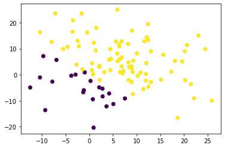

```python
generic1 = load_pickle_dataset('C:/Users/yanga/Desktop/UT/CSCC11/Starter_Code/Logistic_Regression_Problem/datasets/generic_1.pkl')
trainx1 = generic1['train_X']
trainy1 = generic1['train_y']
visualize_2d_data(trainx1, trainy1)
```

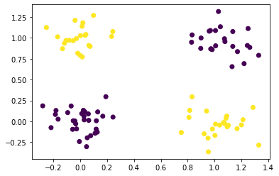

```python
generic2 = load_pickle_dataset('C:/Users/yanga/Desktop/UT/CSCC11/Starter_Code/Logistic_Regression_Problem/datasets/generic_2.pkl')
trainx2 = generic2['train_X']
trainy2 = generic2['train_y']
visualize_2d_data(trainx2, trainy2)
```

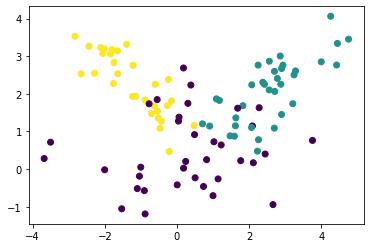

```python
generic3 = load_pickle_dataset('C:/Users/yanga/Desktop/UT/CSCC11/Starter_Code/Logistic_Regression_Problem/datasets/generic_3.pkl')
trainx3 = generic3['train_X']
trainy3 = generic3['train_y']
visualize_2d_data(trainx3, trainy3)
```

*1. Do you expect logistic regression to perform well on generic_1? Why? What if we apply the feature map defined in Eqn. 1.2 ?*

Before implementing LR. There can be a line drawn to separate the two classes, with few points missclassified, feature map can slightly improve performance.

*2. Do you expect logistic regression to perform well on generic_2? Why? What if we apply the feature map defined in Eqn. 1.2 ?*

LR would not work well without feature map, but feature map will improve its performance.

*3. Do you expect logistic regression to perform well on generic_3? Why?*

LR would not work well because some data points are too tangled up with points from another class, even on top of some.

*Generic 1 without and with regularization*

```python
seed = 0
np.random.seed(seed)
dataset_path = 'C:/Users/yanga/Desktop/UT/CSCC11/Starter_Code/Logistic_Regression_Problem/datasets/generic_1.pkl'
data = load_pickle_dataset(dataset_path)

train_X = data['train_X']
train_y = data['train_y']
test_X = test_y = None
test_X = test_y = None


if 'test_X' in data and 'test_y' in data:
    test_X = data['test_X']
    test_y = data['test_y']


factor = 1
bias = 0
alpha_inverse = 0
beta_inverse = 0
num_epochs = 1000
step_size = 1e-3
apply_data_preprocessing = False
check_grad = True
verbose = False

data_preprocessing = lambda X: X
if apply_data_preprocessing :
    data_preprocessing = feature_map

train(train_X=train_X,
        train_y=train_y,
        test_X=test_X,
        test_y=test_y,
        data_preprocessing=data_preprocessing,
        factor=factor,
        bias=bias,
        alpha_inverse=alpha_inverse,
        beta_inverse=beta_inverse,
        num_epochs=num_epochs,
        step_size=step_size,
        check_grad=check_grad,
        verbose=verbose)
```

```
Negative Log Probability: 1.3029910331597623
Analytic Gradient: [[ 0.34251777 -0.34251777]
 [ 2.76298785 -2.76298785]
 [ 5.5288903  -5.5288903 ]]
Numerical Gradient: [[ 0.34251777 -0.34251773]
 [ 2.76298799 -2.76298777]
 [ 5.52889039 -5.52889028]]
The gradients should be nearly identical.
```

[output not shown]

```python
seed = 0
np.random.seed(seed)
dataset_path = 'C:/Users/yanga/Desktop/UT/CSCC11/Starter_Code/Logistic_Regression_Problem/datasets/generic_1.pkl'
data = load_pickle_dataset(dataset_path)

train_X = data['train_X']
train_y = data['train_y']
test_X = test_y = None
test_X = test_y = None


if 'test_X' in data and 'test_y' in data:
    test_X = data['test_X']
    test_y = data['test_y']


factor = 1
bias = 0
alpha_inverse = 2
beta_inverse = 5
num_epochs = 1000
step_size = 1e-3
apply_data_preprocessing = False
check_grad = True
verbose = False

data_preprocessing = lambda X: X
if apply_data_preprocessing :
    data_preprocessing = feature_map

train(train_X=train_X,
        train_y=train_y,
        test_X=test_X,
        test_y=test_y,
        data_preprocessing=data_preprocessing,
        factor=factor,
        bias=bias,
        alpha_inverse=alpha_inverse,
        beta_inverse=beta_inverse,
        num_epochs=num_epochs,
        step_size=step_size,
        check_grad=check_grad,
        verbose=verbose)
```

```
Negative Log Probability: 4.248817958182335
Analytic Gradient: [[ 0.34251777 -0.34251777]
 [ 4.95824187 -0.35193435]
 [ 8.38964777 -3.34935757]]
Numerical Gradient: [[ 0.34251784 -0.34251775]
 [ 4.95824208 -0.35193422]
 [ 8.38964782 -3.3493575 ]]
The gradients should be nearly identical.
Infinitesimal step: 0.0. Terminating gradient descent.
Training Accuracy: 100.0%
Test Accuracy: 100.0%
```

*Question 1* When running without regulariztion, I get error. But when regularization added, the model runs perfectly with no error. Because regularization avoids overfitting and controls function fluctuation so that coefficients dont take extreme values. Accuracies for training and testing sets are 100%.

*Geneic 2 without and with feature map*

```python
seed = 0
np.random.seed(seed)
dataset_path = 'C:/Users/yanga/Desktop/UT/CSCC11/Starter_Code/Logistic_Regression_Problem/datasets/generic_2.pkl'
data = load_pickle_dataset(dataset_path)

train_X = data['train_X']
train_y = data['train_y']
test_X = test_y = None
test_X = test_y = None


if 'test_X' in data and 'test_y' in data:
    test_X = data['test_X']
    test_y = data['test_y']


factor = 1
bias = 0
alpha_inverse = 0
beta_inverse = 0
num_epochs = 1000
step_size = 1e-3
apply_data_preprocessing = False
check_grad = True
verbose = False

data_preprocessing = lambda X: X
if apply_data_preprocessing :
    data_preprocessing = feature_map

train(train_X=train_X,
        train_y=train_y,
        test_X=test_X,
        test_y=test_y,
        data_preprocessing=data_preprocessing,
        factor=factor,
        bias=bias,
        alpha_inverse=alpha_inverse,
        beta_inverse=beta_inverse,
        num_epochs=num_epochs,
        step_size=step_size,
        check_grad=check_grad,
        verbose=verbose)
```

```
Negative Log Probability: 0.6934016709662137
Analytic Gradient: [[-0.03786126  0.03786126]
 [-0.00789853  0.00789853]
 [ 0.00673738 -0.00673738]]
Numerical Gradient: [[-0.03786127  0.03786126]
 [-0.00789854  0.0078985 ]
 [ 0.00673737 -0.00673738]]
The gradients should be nearly identical.
Infinitesimal step: 0.0. Terminating gradient descent.
Training Accuracy: 41.0%
Test Accuracy: 28.000000000000004%
```

```python
seed = 0
np.random.seed(seed)
dataset_path = 'C:/Users/yanga/Desktop/UT/CSCC11/Starter_Code/Logistic_Regression_Problem/datasets/generic_2.pkl'
data = load_pickle_dataset(dataset_path)

train_X = data['train_X']
train_y = data['train_y']
test_X = test_y = None
test_X = test_y = None


if 'test_X' in data and 'test_y' in data:
    test_X = data['test_X']
    test_y = data['test_y']


factor = 1
bias = 0
alpha_inverse = 0
beta_inverse = 0
num_epochs = 1000
step_size = 1e-3
apply_data_preprocessing = True
check_grad = True
verbose = False

data_preprocessing = lambda X: X
if apply_data_preprocessing :
    data_preprocessing = feature_map

train(train_X=train_X,
        train_y=train_y,
        test_X=test_X,
        test_y=test_y,
        data_preprocessing=data_preprocessing,
        factor=factor,
        bias=bias,
        alpha_inverse=alpha_inverse,
        beta_inverse=beta_inverse,
        num_epochs=num_epochs,
        step_size=step_size,
        check_grad=check_grad,
        verbose=verbose)
```

```
Negative Log Probability: 0.6999267532884842
Analytic Gradient: [[-0.01998411  0.01998411]
 [ 0.00396067 -0.00396067]
 [ 0.02117265 -0.02117265]
 [-0.11066245  0.11066245]]
Numerical Gradient: [[-0.01998408  0.01998415]
 [ 0.0039607  -0.00396063]
 [ 0.02117269 -0.02117262]
 [-0.11066241  0.1106625 ]]
The gradients should be nearly identical.
Training Accuracy: 100.0%
Test Accuracy: 100.0%
```

*Q1 continued*

When without feature map, accuracy for training set is below 50%, and even lower for testing set. But with feature map I get 100% accuracy as predicted in written part. Because feature map adds an additional constraint that improves classification accuracy.

*Generic 3 without and with feature map*

```python
seed = 0
np.random.seed(seed)
dataset_path = 'C:/Users/yanga/Desktop/UT/CSCC11/Starter_Code/Logistic_Regression_Problem/datasets/generic_3.pkl'
data = load_pickle_dataset(dataset_path)

train_X = data['train_X']
train_y = data['train_y']
test_X = test_y = None
test_X = test_y = None


if 'test_X' in data and 'test_y' in data:
    test_X = data['test_X']
    test_y = data['test_y']


factor = 1
bias = 0
alpha_inverse = 0
beta_inverse = 0
num_epochs = 1000
step_size = 1e-3
apply_data_preprocessing = False
check_grad = True
verbose = False

data_preprocessing = lambda X: X
if apply_data_preprocessing :
    data_preprocessing = feature_map

train(train_X=train_X,
        train_y=train_y,
        test_X=test_X,
        test_y=test_y,
        data_preprocessing=data_preprocessing,
        factor=factor,
        bias=bias,
        alpha_inverse=alpha_inverse,
        beta_inverse=beta_inverse,
        num_epochs=num_epochs,
        step_size=step_size,
        check_grad=check_grad,
        verbose=verbose)
```

```
Negative Log Probability: 1.0527303893394206
Analytic Gradient: [[ 0.028495   -0.0467047   0.0182097 ]
 [ 0.17864116 -0.62783493  0.44919377]
 [ 0.47239894 -0.28605545 -0.18634349]]
Numerical Gradient: [[ 0.02849503 -0.04670473  0.01820968]
 [ 0.17864115 -0.62783492  0.44919377]
 [ 0.47239894 -0.28605545 -0.1863435 ]]
The gradients should be nearly identical.
Infinitesimal step: 0.0. Terminating gradient descent.
Training Accuracy: 79.0%
Test Accuracy: 82.0%
```

```python
seed = 0
np.random.seed(seed)
dataset_path = 'C:/Users/yanga/Desktop/UT/CSCC11/Starter_Code/Logistic_Regression_Problem/datasets/generic_3.pkl'
data = load_pickle_dataset(dataset_path)

train_X = data['train_X']
train_y = data['train_y']
test_X = test_y = None
test_X = test_y = None


if 'test_X' in data and 'test_y' in data:
    test_X = data['test_X']
    test_y = data['test_y']


factor = 1
bias = 0
alpha_inverse = 0
beta_inverse = 0
num_epochs = 1000
step_size = 1e-3
apply_data_preprocessing = True
check_grad = True
verbose = False

data_preprocessing = lambda X: X
if apply_data_preprocessing :
    data_preprocessing = feature_map

train(train_X=train_X,
        train_y=train_y,
        test_X=test_X,
        test_y=test_y,
        data_preprocessing=data_preprocessing,
        factor=factor,
        bias=bias,
        alpha_inverse=alpha_inverse,
        beta_inverse=beta_inverse,
        num_epochs=num_epochs,
        step_size=step_size,
        check_grad=check_grad,
        verbose=verbose)
```

```
Negative Log Probability: 1.836152929091935
Analytic Gradient: [[-0.03962738 -0.14654356  0.18617094]
 [-0.19974318 -0.88297108  1.08271426]
 [ 0.33105306 -0.51007556  0.1790225 ]
 [-0.57079599 -2.16482874  2.73562473]]
Numerical Gradient: [[-0.0396273  -0.14654351  0.18617099]
 [-0.19974316 -0.88297101  1.08271432]
 [ 0.33105316 -0.51007554  0.17902255]
 [-0.57079592 -2.16482872  2.73562482]]
The gradients should be nearly identical.
Infinitesimal step: 0.0. Terminating gradient descent.
Training Accuracy: 83.0%
Test Accuracy: 82.0%
```

*Question 2*

Without feature map, accuracies for training and testing sets are 79% and 82%. With feature map, corresponding accuracies are now 83% and 82%

*Wine with regularization*

```python
seed = 0
np.random.seed(seed)
dataset_path = 'C:/Users/yanga/Desktop/UT/CSCC11/Starter_Code/Logistic_Regression_Problem/datasets/wine.pkl'
data = load_pickle_dataset(dataset_path)

train_X = data['train_X']
train_y = data['train_y']
test_X = test_y = None
test_X = test_y = None


if 'test_X' in data and 'test_y' in data:
    test_X = data['test_X']
    test_y = data['test_y']


factor = 1
bias = 0
alpha_inverse = 2
beta_inverse = 5
num_epochs = 1000
step_size = 1e-3
apply_data_preprocessing = False
check_grad = True
verbose = False

data_preprocessing = lambda X: X
if apply_data_preprocessing :
    data_preprocessing = feature_map

train(train_X=train_X,
        train_y=train_y,
        test_X=test_X,
        test_y=test_y,
        data_preprocessing=data_preprocessing,
        factor=factor,
        bias=bias,
        alpha_inverse=alpha_inverse,
        beta_inverse=beta_inverse,
        num_epochs=num_epochs,
        step_size=step_size,
        check_grad=check_grad,
        verbose=verbose)
```

```
Negative Log Probability: 32.8558262978161
Analytic Gradient: [[-0.02933657 -0.03979514  0.06913171]
 [ 1.82325069  4.19756983  0.4502332 ]
 [ 3.01521144  0.2519266   3.65643932]
 [ 2.34187551  0.47491114  2.03017734]
 [ 2.56782984 -0.23357593  1.58480017]
 [ 1.49486624  3.60302193  0.98543286]
 [ 2.29220293  3.26973212  3.23120316]
 [ 1.43293298  3.59494119  2.0271246 ]
 [ 3.8110567   3.80758932  2.13665514]
 [ 3.71370488  3.29880596  0.11393367]
 [ 1.43517392  2.22533091  2.18972068]
 [ 2.98034749  3.08718877  2.66986349]
 [ 1.88262463  0.43185736  2.74193138]
 [ 1.78149727  3.02603847  3.7993189 ]]
Numerical Gradient: [[-0.02933689 -0.03979537  0.06913154]
 [ 1.82325053  4.19756958  0.45023327]
 [ 3.01521155  0.25192648  3.65643871]
 [ 2.34187567  0.47491113  2.03017692]
 [ 2.56782968 -0.233576    1.58479949]
 [ 1.4948661   3.60302153  0.98543254]
 [ 2.29220305  3.26973151  3.23120304]
 [ 1.43293235  3.59494123  2.02712442]
 [ 3.81105636  3.80758962  2.1366553 ]
 [ 3.7137049   3.29880621  0.1139334 ]
 [ 1.4351734   2.22533103  2.18972076]
 [ 2.98034735  3.08718882  2.66986362]
 [ 1.8826249   0.43185722  2.74193113]
 [ 1.78149762  3.02603809  3.7993189 ]]
The gradients should be nearly identical.
Infinitesimal step: 0.0. Terminating gradient descent.
Training Accuracy: 95.27027027027027%
Test Accuracy: 96.66666666666667%
```

*Question 3*

Model performs good for wine dataset. With training and testing accuracies at 95% and 96%